# Jingda-hw2

#### 9. Export the Pickle model and import it back. Use the imported model to predict the y_test from x_test and report the confusion matrix

```python
stacked_classifier_g10 = StackingClassifier(estimators=level0, final_estimator=LogisticRegression(max_iter=1000))
stacked_classifier_g10.fit(X_train_g10, y_train_g10)
```

```
StackingClassifier(estimators=[('knn', KNeighborsClassifier()),
                               ('cart', DecisionTreeClassifier()),
                               ('svc', SVC(probability=True)),
                               ('rf', RandomForestClassifier())],
                   final_estimator=LogisticRegression(max_iter=1000))
```

```python
import pickle
filename = 'stacked_classifier_model.pkl'

#save model
with open(filename, 'wb') as file:
    pickle.dump(stacked_classifier_g10, file)

#import model
with open(filename, 'rb') as file:
    loaded_classifier = pickle.load(file)

#prediction
y_pred_imported_g10 = loaded_classifier.predict(X_test_g10)

#show the confusion matrix for the imported model's predictions
cm_imported_g10 = confusion_matrix(y_test_g10, y_pred_imported_g10)
print("\nConfusion Matrix for Imported Stacked Classifier:")
print(cm_imported_g10)
```

```
Confusion Matrix for Imported Stacked Classifier:
[[85283    11]
 [   30   119]]
```

#### 10. Show both text and visual confusion Matrices using scikit learn and matplotlib and explain what the graph tells you and what you did.

```
Confusion Matrix:
[[85283    11]
 [   30   119]]
```

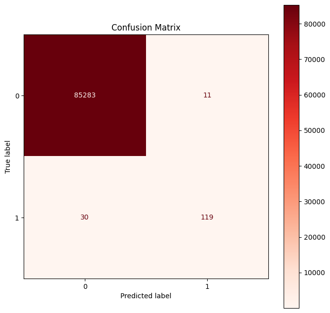

```python
import matplotlib.pyplot as plt
from sklearn.metrics import confusion_matrix, ConfusionMatrixDisplay

#calculate cm
cm_g10 = confusion_matrix(y_test_g10, y_pred_imported_g10)

#show text confusion matrix
print("Confusion Matrix:")
print(cm_g10)

#show the cm
fig, ax = plt.subplots(figsize=(8, 8))
disp = ConfusionMatrixDisplay(confusion_matrix=cm_g10)
disp.plot(ax=ax, cmap=plt.cm.Reds)
plt.title("Confusion Matrix")
plt.show()
```

85283 (True Negatives): This represents the total count of genuine transactions that the model accurately identified as such.

11 (False Positives): These are the authentic transactions that the model mistakenly flagged as fraudulent.

30 (False Negatives): These signify the actual fraudulent transactions that the model failed to detect and incorrectly labeled as legitimate.

119 (True Positives): This count denotes the instances where the model correctly pinpointed transactions as fraudulent.